# RAiN analysis

Nicolas Legewie

11/30/2021

### To Do

- Check Small stuff for angles
- Add to data quality: by Batch, comparison excluded v. included
- Change SES of origin in demo & SES descriptives to highest degree between two parents
- Change histograms to percent
- Fix issue with code for `act_instancesEmo`: For two respondents output is `-Inf`
- Income descr plot: NAs are not displayed
- Rate of match: Activation ties v. “important ties”
- Differences in tie numbers: age, gender, race, education, income
- Differences in activation instances: age, gender, race, SES
- Differences in rate of match: age, gender, race, SES

### Data quality

Overall, our analysis suggests that about 10% of our initial respondents were in fact not US residents.

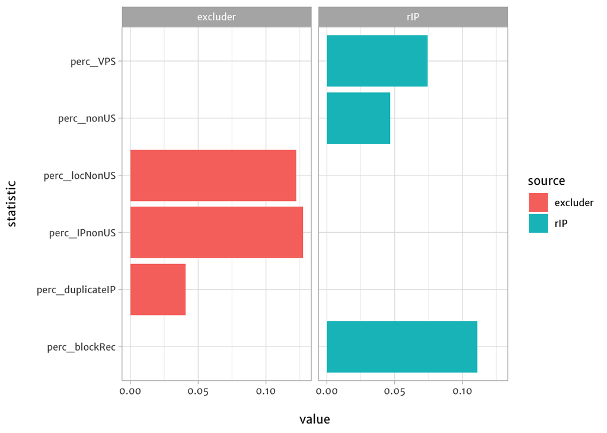

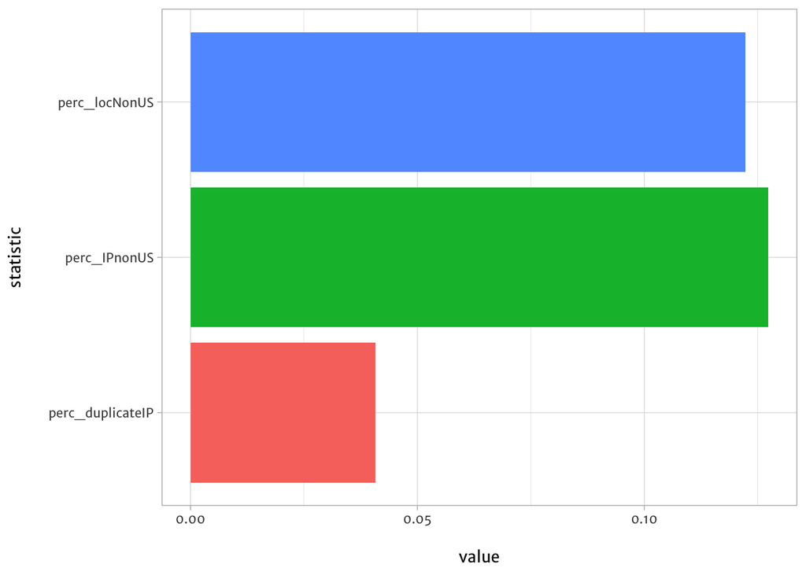

## Demographics and SES

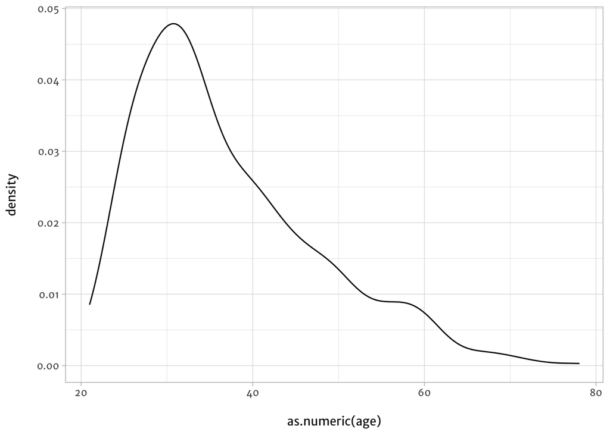

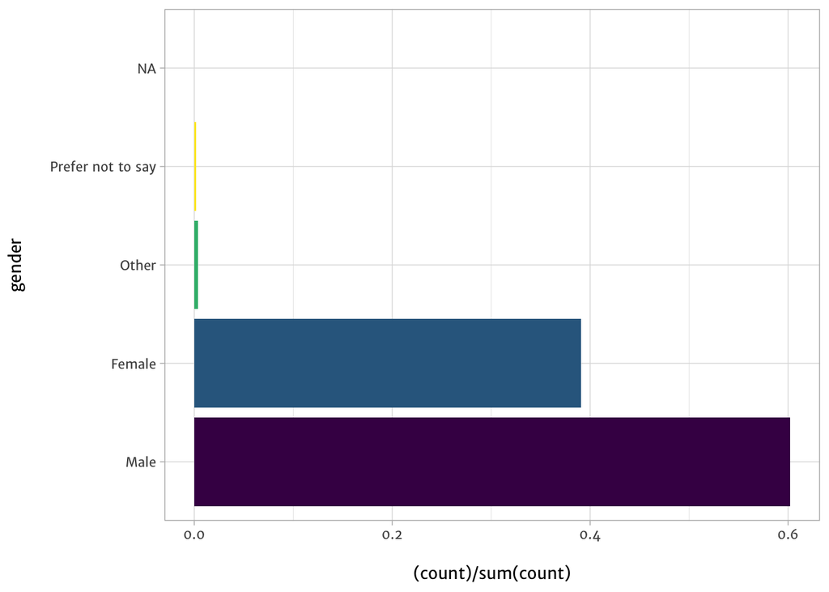

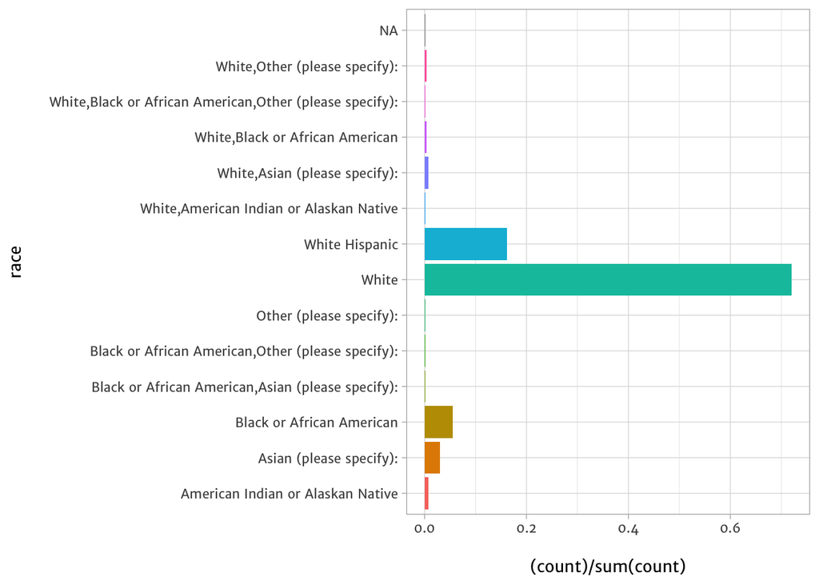

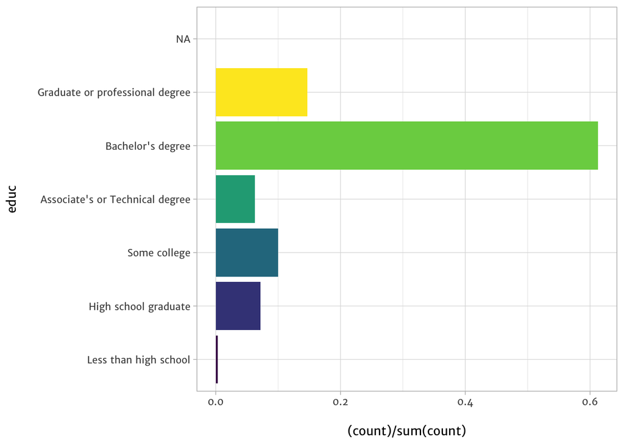

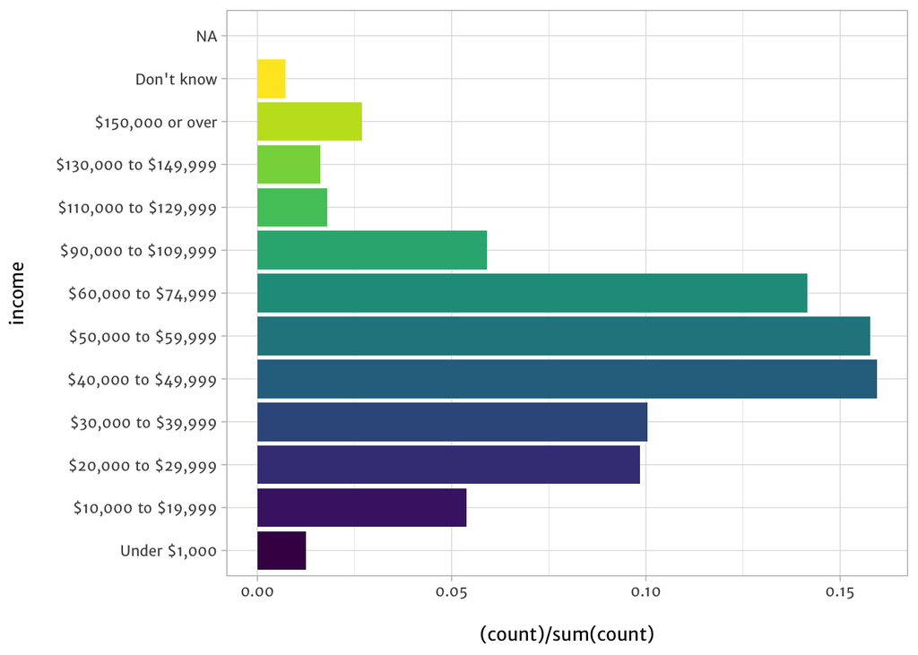

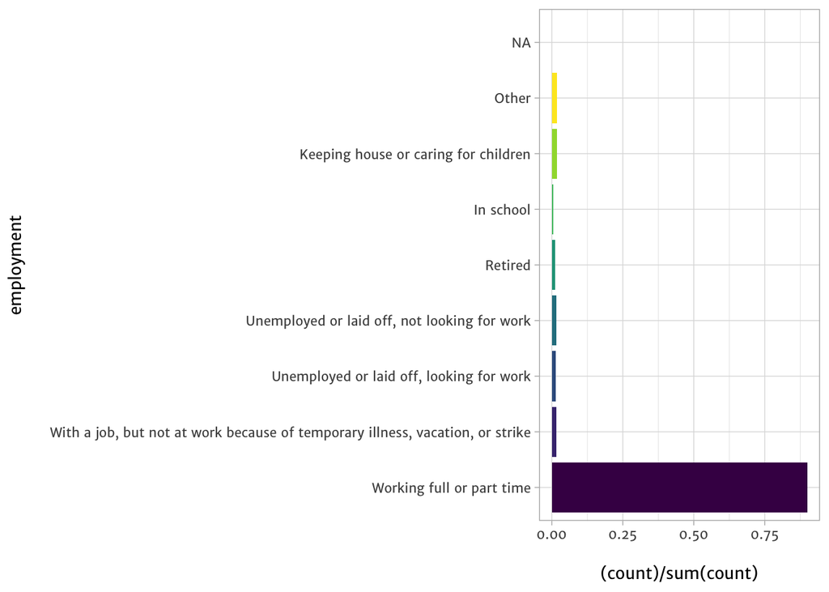

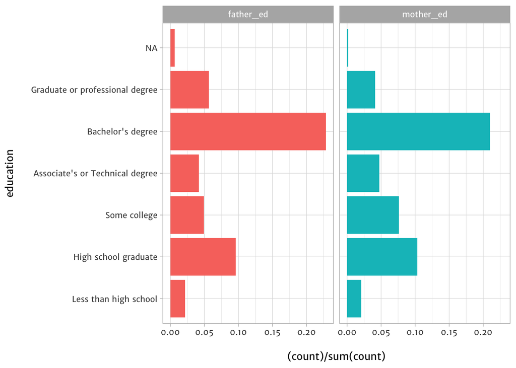

## Personal network and support activation

The plots show that we have what I believe to be a data quality problem: Many people seem to fill out all windows when asked for activation examples, alters they talked to in each example, and important people. Not sure how we can fix this. With activation alters, we may exclude, as a robustness check at least, everyone who filled out all 9 possible activation examples, and all alters for each example. With important people we probably shouldn’t do anything, it’s very possible that many people fill out all five slots for both family and non-family important people. Maybe we could exclude those people here as well who filled up everything for tie activation.

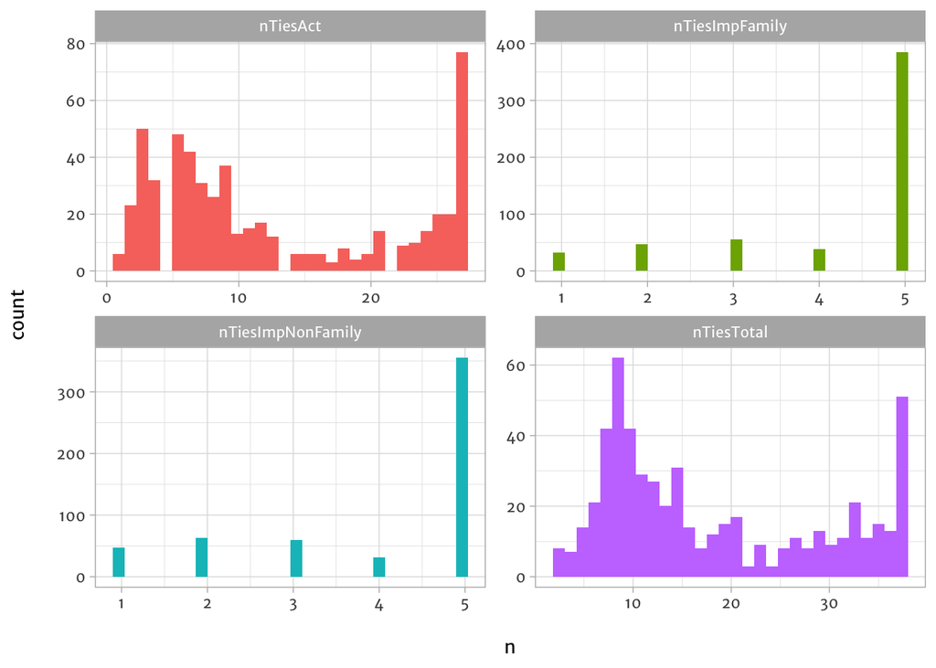

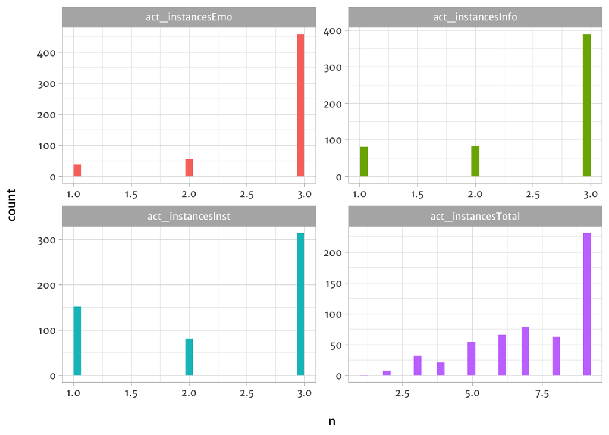

Here’s the plots with all respondents nTiesAct == 27 filtered out. Looking at the distributions of `nTiesAct` and `nTiesTotal`, to me this looks more realistic. Still, it’s probably better to use a filter based on more than one of our flags. For instance, the IP address check, as well as others.

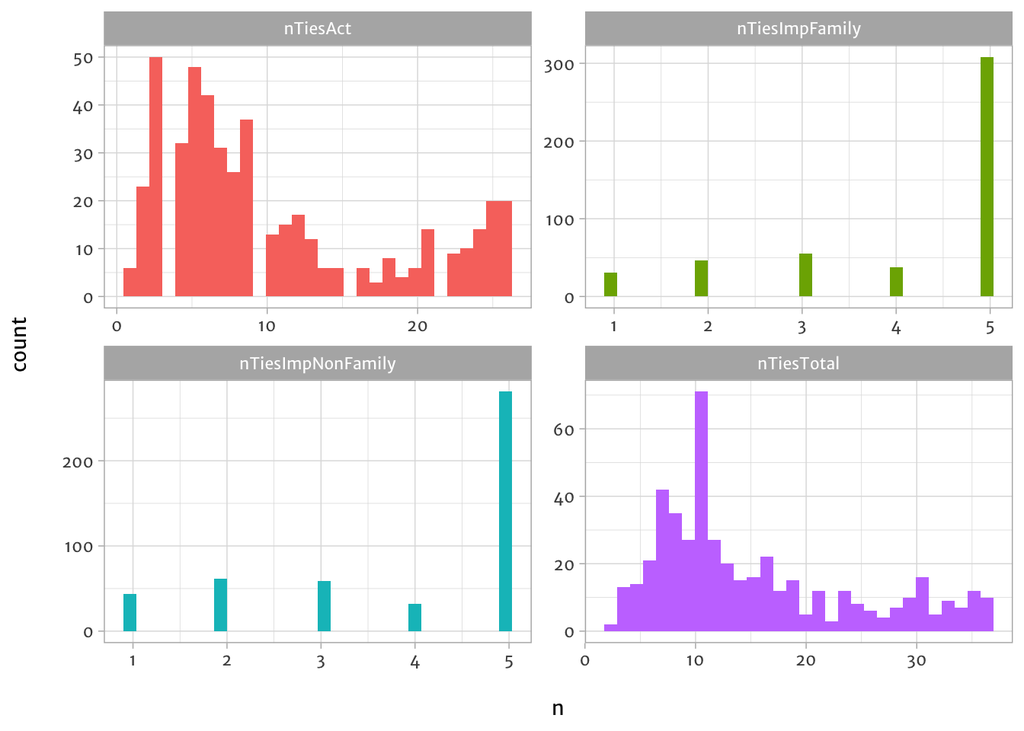

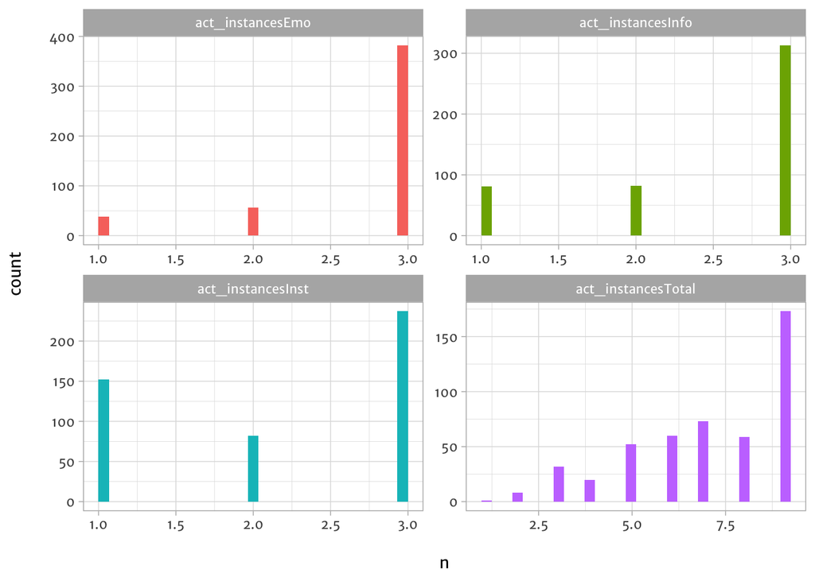

```
## # A tibble: 555 × 5
##    ResponseId        MID            nTiesAct nTiesAct_impFam nTiesAct_impNonFam
##    <chr>             <chr>             <dbl> <list>          <list>
##  1 R_2DZUEpiyK6Jk6sJ A1143GKN5T807X        4 <int [1]>       <int [1]>
##  2 R_3jTMN0oXTJpteJb A1QUQ0TV9KVD4C        9 <int [1]>       <int [1]>
##  3 R_2R7UogjCC3VtBeA AHJH5S80O5JBY         9 <int [1]>       <int [1]>
##  4 R_1Pe09SYh3q33BTg A3I8W5848LIHPC       27 <int [0]>       <int [0]>
##  5 R_RgLd0APHzgtaWIx AZMOA8ONG0D2U         5 <int [1]>       <int [0]>
##  6 R_3HoFC1nYMMlerua A2CWADQFILGY80       27 <int [0]>       <int [0]>
##  7 R_Qp3Bpep68Ooi0QF A353C9DQDQ4JHP       27 <int [0]>       <int [0]>
##  8 R_4SDXELdPO25cIJH A3SACNWNF16TPT       27 <int [0]>       <int [1]>
##  9 R_vrATJt7Plj5R0CR A1O5IL3N3G3WIL        3 <int [0]>       <int [1]>
## 10 R_2zjpcdWFsxA6Fe9 A1UDOSYE75OYYI        3 <int [1]>       <int [0]>
## # … with 545 more rows
```